# Some Thoughts on Summarising Longitudinal Transaction Behaviour

# Recency

**Recency** metrics measure how recently a customer was last active.

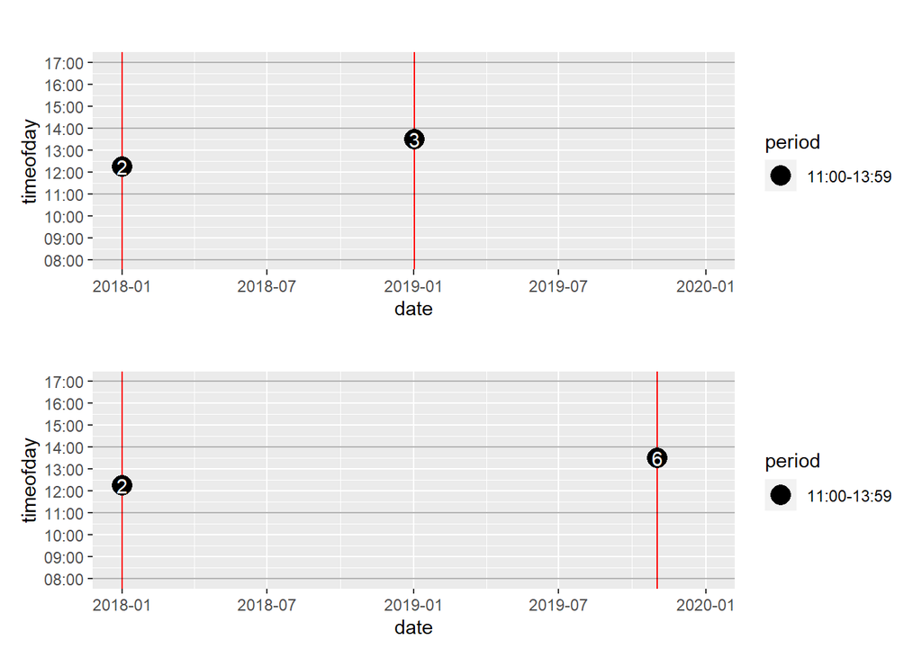

Features describing **recency**:

1. Number of days since last transaction.
2. Number of days since $x^{th}$-last transaction (e.g. how many days ago was their 5th most recent transaction?). If the customer does not have $x$ transactions, then we can calculate the mean number of days between their existing transactions, and multiply this by $x$.
3. Number of days since customer had $x$ close transactions (e.g. how many days ago did customer have 3 transactions, where those transactions were a maximum of 1 month apart). This is a stricter definition of an *active* customer, requiring a number of transactions in close proximity in time to define them as *active* - 1 or 2 transactions is not enough to free a customer of their *dormancy* label.

# Consistency

How consistent is a customer in their transactions, in terms of amount of time between each transaction? Does the customer shop regularly and periodically, or intermittently?

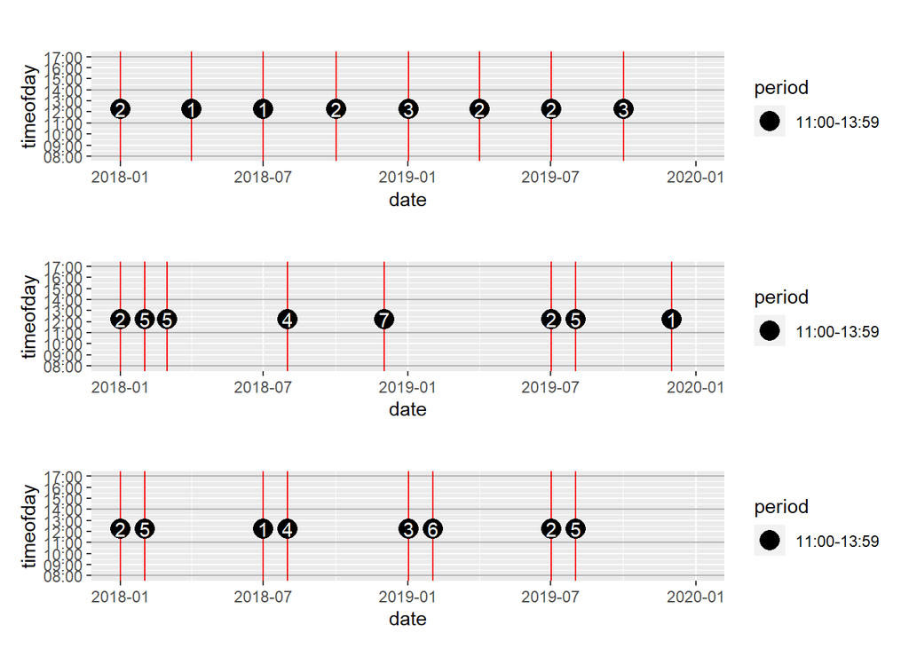

Meausures of consistency:

1. Standard Deviation of Gap Length (gap length=number of days between 2 transactions).
2. Standard Deviation of gap length, where data is first binned into active weeks (week containing at least one transaction) and inactive weeks (week containing no transactions). *Gap length* is then defined as number of inactive weeks between two active weeks. Could also bin transactions into *active* and *inactive* *months*.

# Trajectory

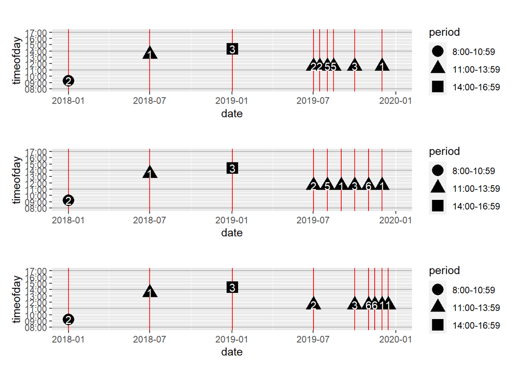

Measures of trajectory:

```
##    customer_id  gaplength_trajectory_last12_months
## 0            1                                 0.0
## 1            2                               -45.5
```

Example of trajectory of gap-lengths: consider the following customer:

| transaction_datetime |
| --- |
| 2018-01-01 09:15:00 |
| 2018-07-01 13:30:02 |
| 2019-01-01 14:22:02 |
| 2019-07-01 11:35:58 |
| 2019-10-01 11:35:58 |
| 2019-11-01 11:35:58 |
| 2019-11-15 11:35:58 |
| 2019-12-01 11:35:58 |
| 2019-12-15 11:35:58 |

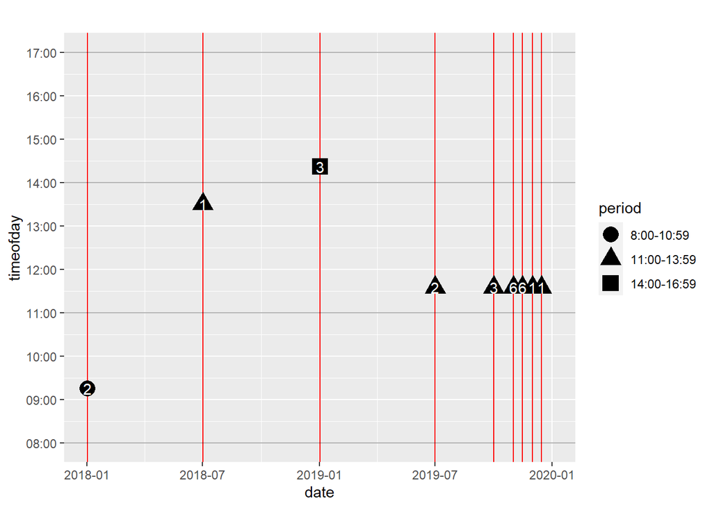

The gap lengths between the transactions (*days since previous transaction*) in the last 12 months for this customer are:

| transaction_id | transaction_datetime | days_since_previous_transaction | transaction_num |
| --- | --- | --- | --- |
| 3 | 2019-01-01 14:22:02 | NA | NA |
| 4 | 2019-07-01 11:35:58 | 180 | 0 |
| 5 | 2019-10-01 11:35:58 | 92 | 1 |
| 6 | 2019-11-01 11:35:58 | 31 | 2 |
| 7 | 2019-11-15 11:35:58 | 14 | 3 |
| 8 | 2019-12-01 11:35:58 | 16 | 4 |
| 9 | 2019-12-15 11:35:58 | 14 | 5 |

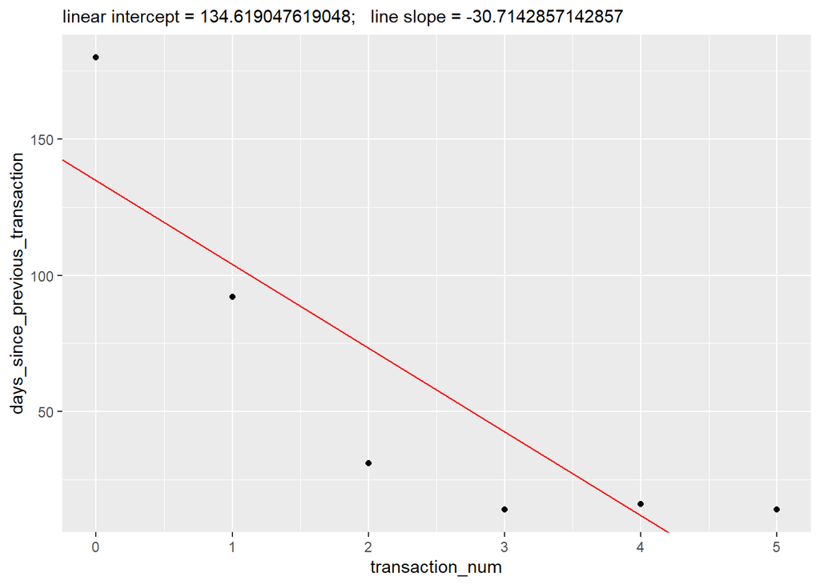

There is a linearly decreasing trajectory of gap-lengths for this customer (times between transactions is decreasing in the past 12 months for this customer).

```
##    customer_id  gaplength_trajectory_last12_months
## 0            1                          -30.714286
```

# Frequency

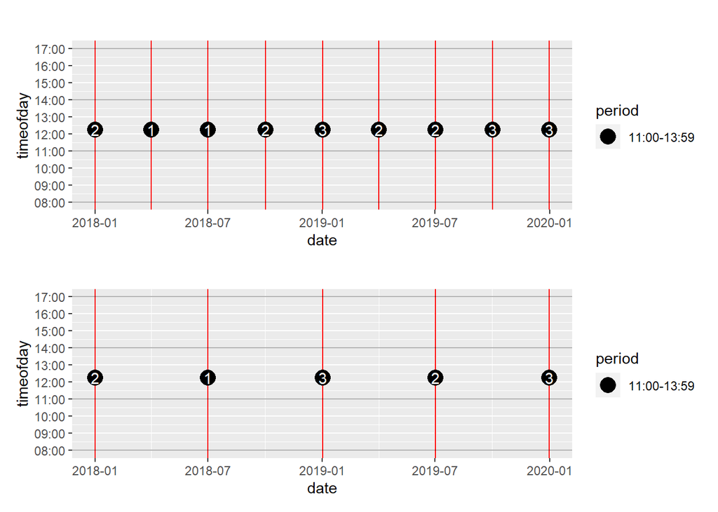

Measures of frequency:

1. Number of transactions in last $x$ weeks. Note: If customer’s first transaction was less than $x$ weeks ago, then consider number of transactions since first transaction date.
2. Minimum and Maximum gap-length (time between any 2 transactions) in last $x$ months.

```
##    customer_id  n_transactions_last_6_months
## 0            1                             1
## 1            2                             2
## 2            3                             0
```

# Day-of-Week Preference

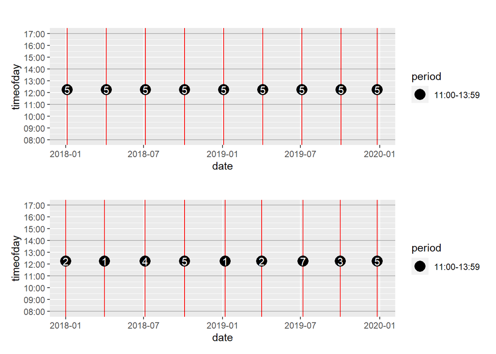

Measures of *Day-of-Week Preference*: 1. Proportion of transactions at each each Day-of-Week (7 separate features).

2. Gini coefficient for proportion of transactions at each each day-of-Week.

# Time-of-Day Preference

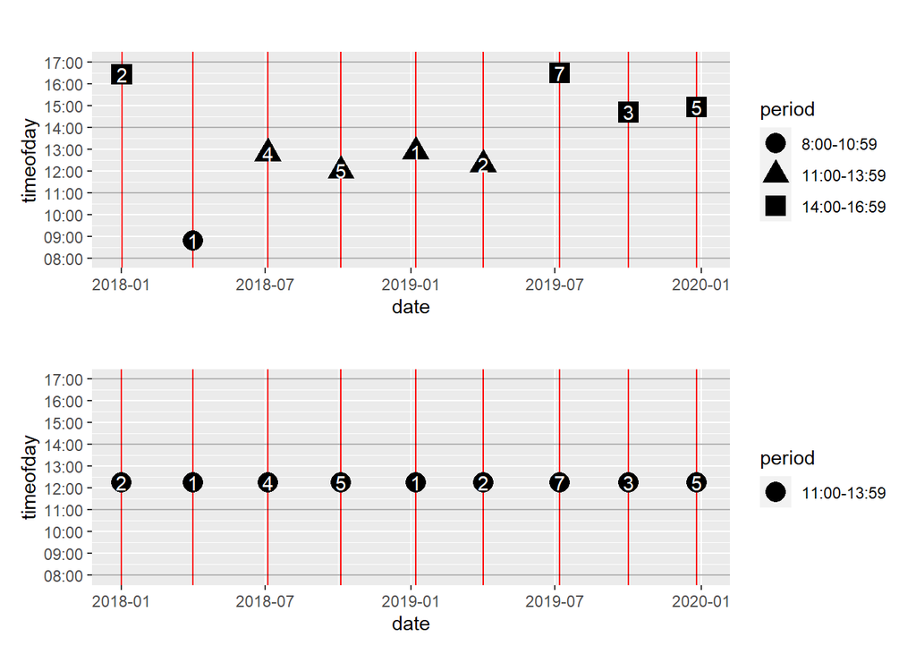

1. Proportion of transactions at each each time-of-day (3 separate features).
2. Gini coefficient for proportion of transactions at each time-of-day.

# Change in behaviour regime

Compare change in various metrics over 2 consecutive periods.

# Simulate 1000 random customers:

```r
sim_customers <-
  customer_sim_results(n_customers = 1000) %>%
    rename( transaction_datetime = transaction_datetime )

nrow(sim_customers)
```

```
## [1] 10120
```

Here are the first 20 rows of this dataset

```r
sim_customers %>% head(20)
```

| customer_id | transaction_datetime |
| --- | --- |
| 1 | 2018-02-01 08:38:11 |
| 1 | 2018-06-09 14:53:23 |
| 1 | 2018-06-21 14:29:23 |
| 1 | 2018-07-20 08:40:09 |
| 1 | 2018-08-16 08:47:28 |
| 1 | 2018-08-27 12:51:35 |
| 1 | 2018-09-27 10:20:11 |
| 1 | 2018-12-22 10:11:59 |
| 1 | 2018-12-30 10:41:33 |
| 1 | 2019-03-30 08:13:30 |

[output cut: 10 more lines]

```python
# read in the CSV:
transactiondata = pd.read_csv( 'C:/Users/Joe/Desktop/temp.csv' )

# get number of days since last transaction:
num_days_since_last_transaction = num_days_since_xth_last_transaction( customerdata = transactiondata,
                                                                       period_end_datetime = '2020-01-01 00:00:00',
                                                                       x_transactions = 1
                                                                     )


# get number of days since 5th last transaction:
num_days_since_5th_last_transaction = num_days_since_xth_last_transaction(         customerdata = transactiondata,
                                                                            period_end_datetime = '2020-01-01 00:00:00',
                                                                                 x_transactions = 5
                                                                          )

# get std dev of gap-length in last year:
std_dev_gaplength_last_12_months = get_std_dev_gaplength_last_x_months(        customerdata = transactiondata,
                                                                        period_end_datetime = '2020-01-01 00:00:00',
                                                                                   x_months = 12
                                                                   )

# get std dev of gap-length in last 6 months:
std_dev_gaplength_last_06_months = get_std_dev_gaplength_last_x_months(        customerdata = transactiondata,
                                                                        period_end_datetime = '2020-01-01 00:00:00',
                                                                                   x_months = 6
                                                                   )

# get min and max gap-length in last 6 months:
minmax_gaplen_last_06_months = minmax_gaplength_last_x_months(        customerdata = transactiondata,
                                                               period_end_datetime = '2020-01-01 00:00:00',
                                                                          x_months = 6
                                                             )


# get linear trajectory of gap-lengths in last 6 months:
linear_gaplength_trajectory_last_06_months = linear_gaplength_trajectory_last_x_months(
                                                                                          customerdata = transactiondata,
                                                                                   period_end_datetime = '2020-01-01 00:00:00',
                                                                                              x_months = 6
                                                                                       )

# get linear trajectory of gap-lengths in last 12 months:
linear_gaplength_trajectory_last_12_months = linear_gaplength_trajectory_last_x_months(
                                                                                          customerdata = transactiondata,
                                                                                   period_end_datetime = '2020-01-01 00:00:00',
                                                                                              x_months = 12
                                                                                       )

# get proportion of transactions by weekday:
transaction_dayofweek_proportions_last_24_months = prop_by_dayofweek_last_x_months(        customerdata = transactiondata,
                                                                                    period_end_datetime = '2020-01-01 00:00:00',
                                                                                          last_x_months = 24
                                                             )


# join all results into one dataframe:
final_features = transactiondata[['customer_id']].drop_duplicates()       # list of all unique customer IDs

final_features = pd.merge( final_features,
                           num_days_since_last_transaction,
                           on = 'customer_id',
                           how = 'left'
                        )

final_features = pd.merge( final_features,
                           num_days_since_5th_last_transaction,
                           on = 'customer_id',
                           how = 'left'
                        )

final_features = pd.merge( final_features,
                           std_dev_gaplength_last_06_months,
                           on = 'customer_id',
                           how = 'left'
                        )

final_features = pd.merge( final_features,
                           std_dev_gaplength_last_12_months,
                           on = 'customer_id',
                           how = 'left'
                        )

final_features = pd.merge( final_features,
                           minmax_gaplen_last_06_months,
                           on = 'customer_id',
                           how = 'left'
                        )

final_features = pd.merge( final_features,
                           linear_gaplength_trajectory_last_06_months,
                           on = 'customer_id',
                           how = 'left'
                        )

final_features = pd.merge( final_features,
                           linear_gaplength_trajectory_last_12_months,
                           on = 'customer_id',
                           how = 'left'
                        )

final_features = pd.merge( final_features,
                           transaction_dayofweek_proportions_last_24_months,
                           on = 'customer_id',
                           how = 'left'
                        )

# export to csv:
# (overwriting previous file)
final_features.to_csv('C:/Users/Joe/Desktop/temp.csv')
```

Look at a few random customers, with their calculated features:

```
## [1] "Customer ID:"
## [1] 127
```

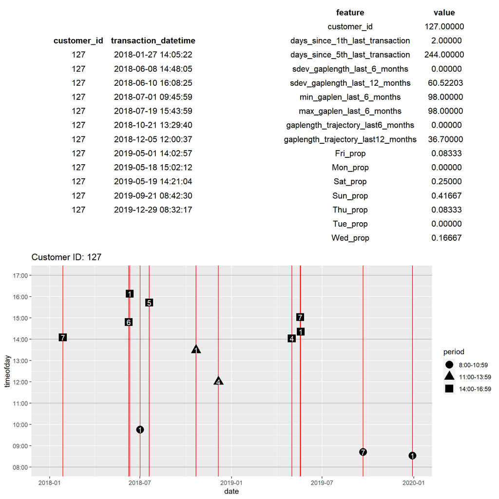

```
## [1] "Customer ID:"
## [1] 25
```

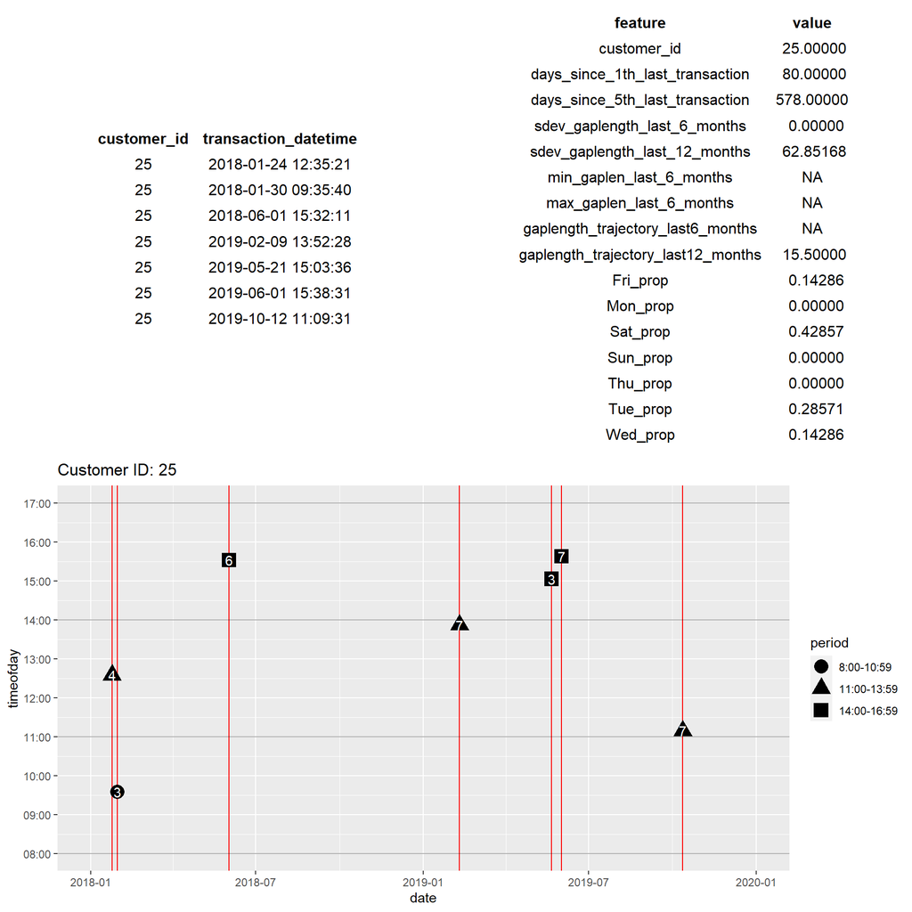

```
## [1] "Customer ID:"
## [1] 933
```

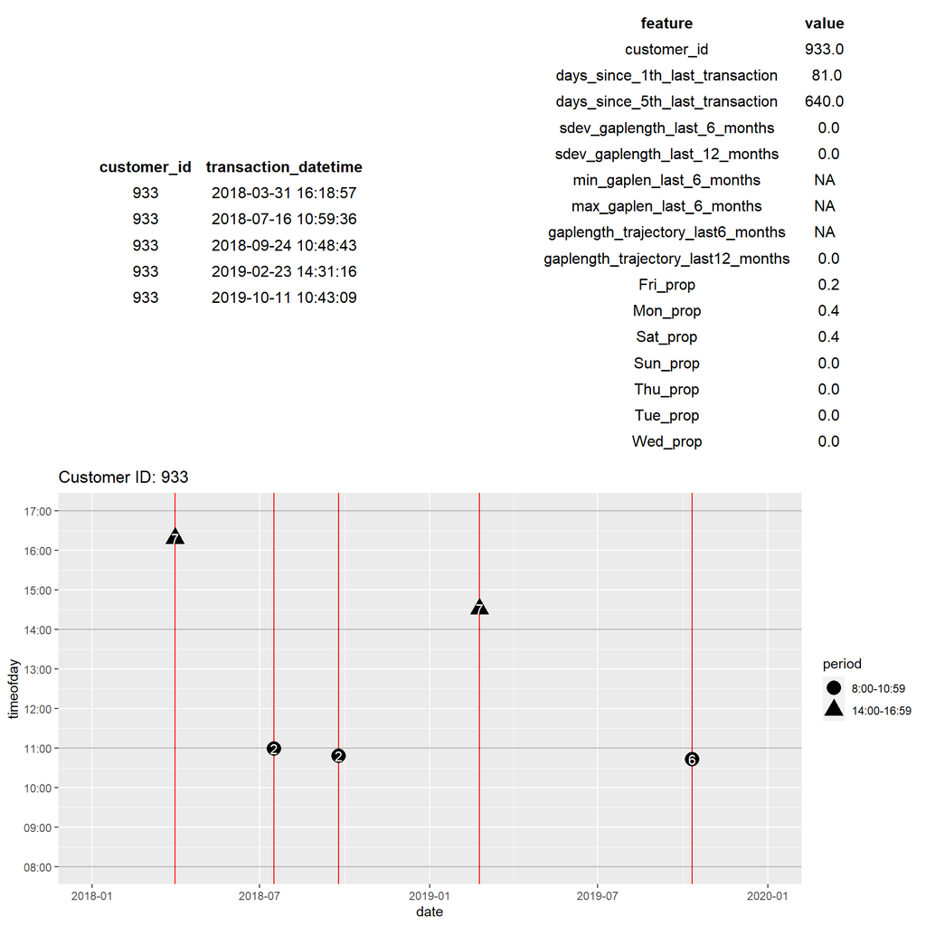

```
## [1] "Customer ID:"
## [1] 939
```

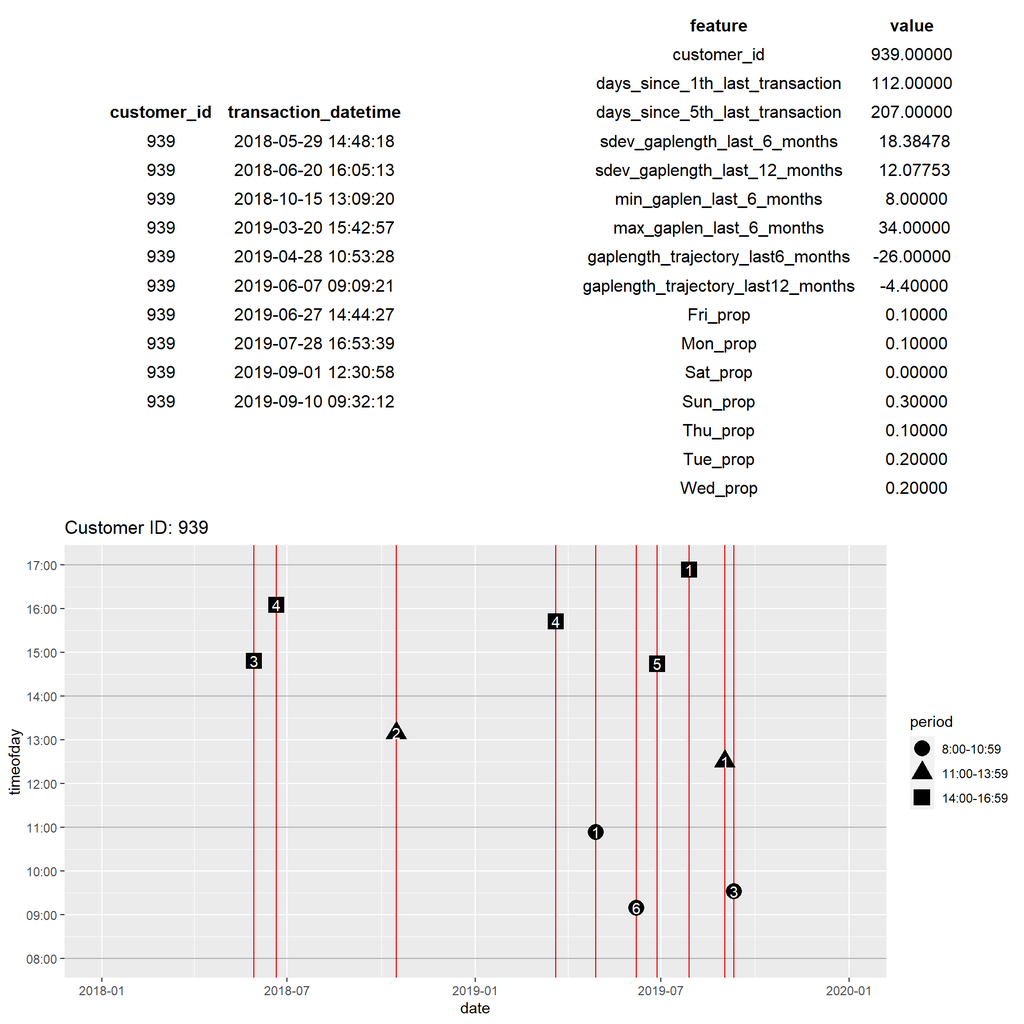

```
## [1] "Customer ID:"
## [1] 259
```

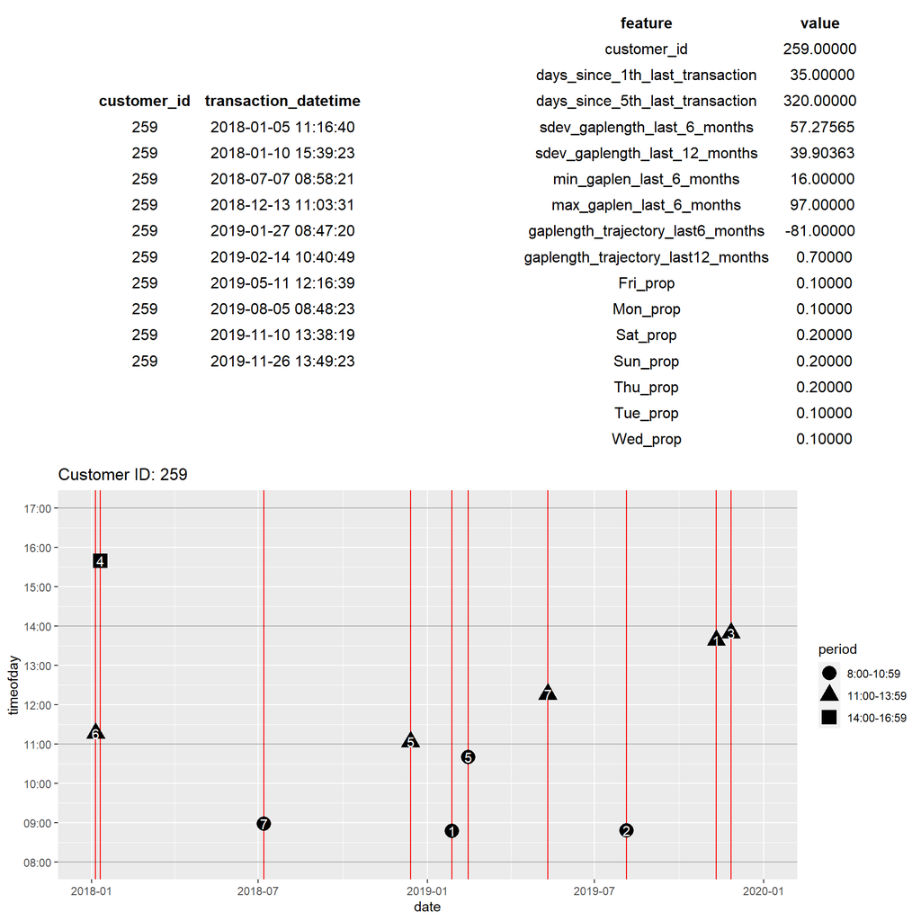

```
## [1] "Customer ID:"
## [1] 155
```

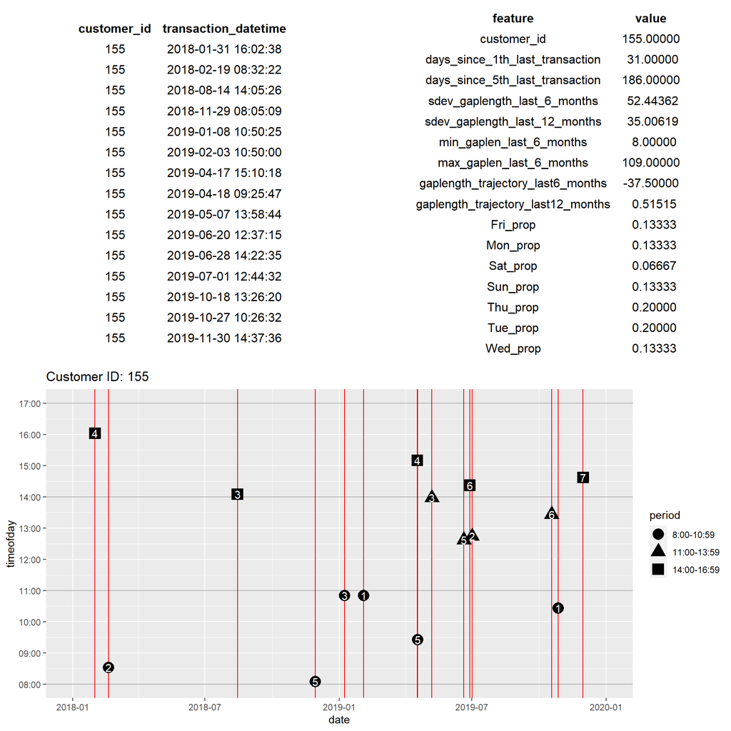

```
## [1] "Customer ID:"
## [1] 420
```

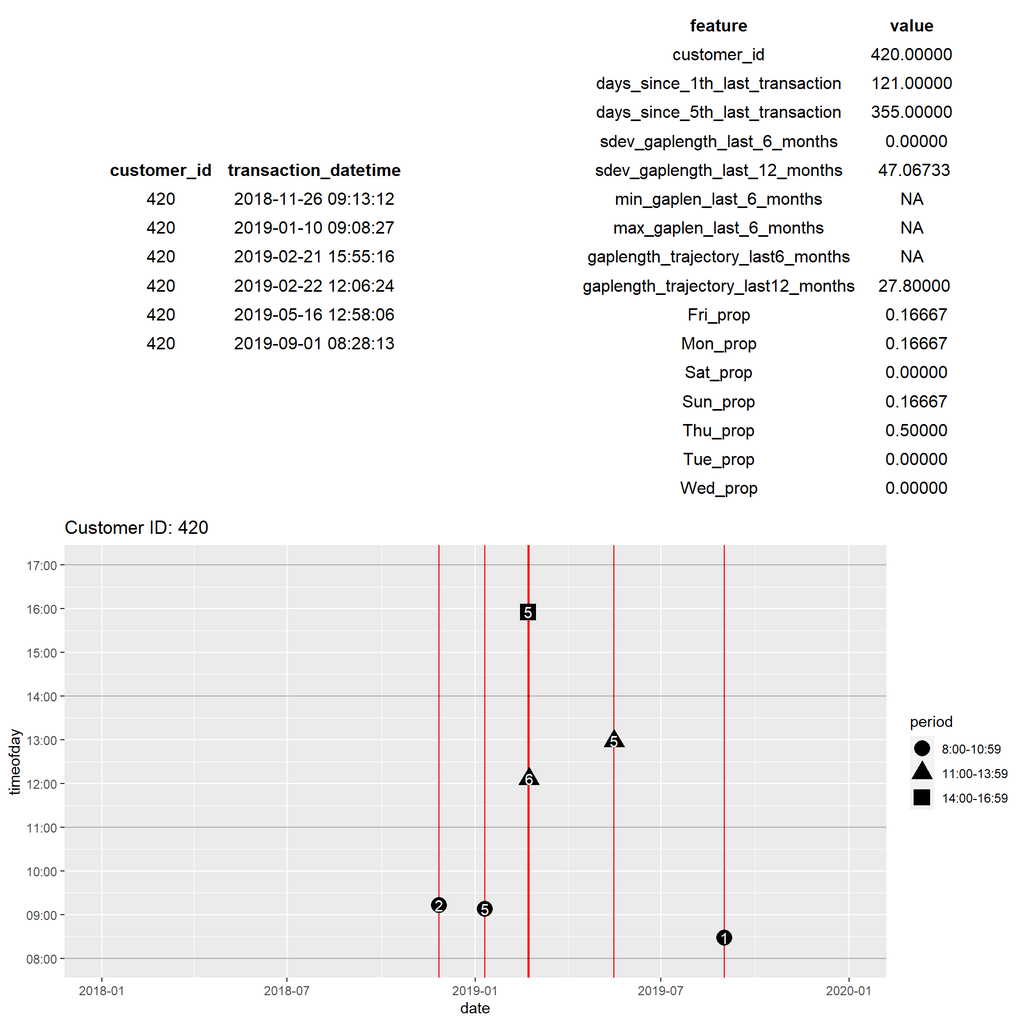

```
## [1] "Customer ID:"
## [1] 477
```

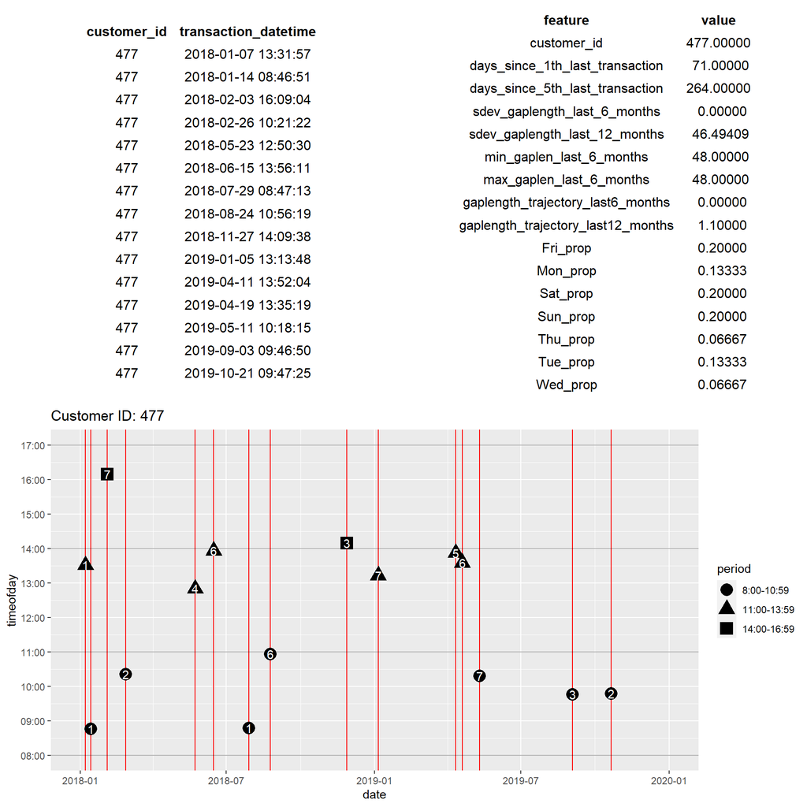

```
## [1] "Customer ID:"
## [1] 978
```

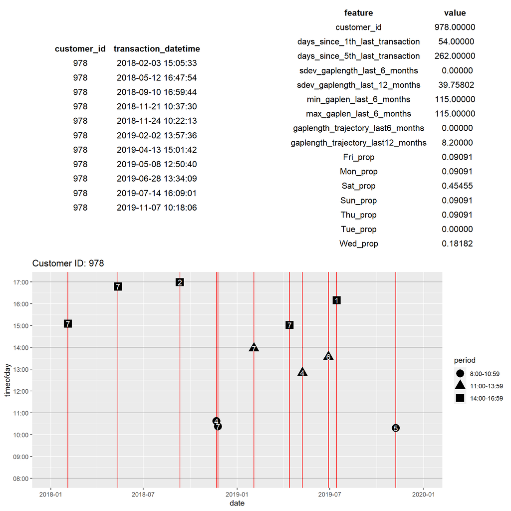

```
## [1] "Customer ID:"
## [1] 578
```

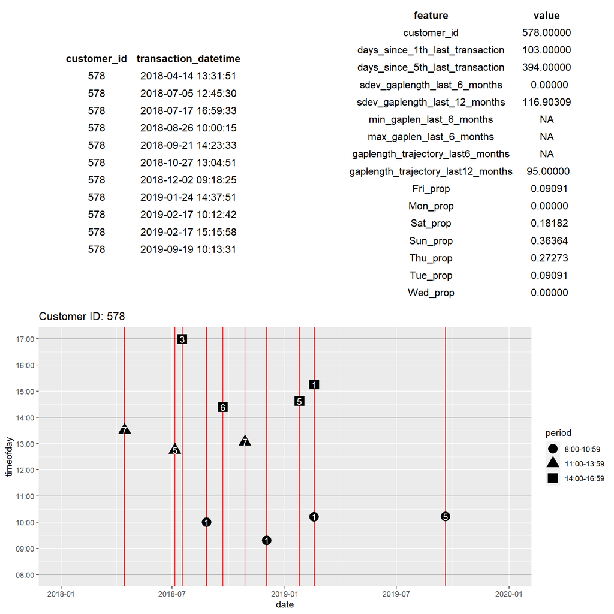

```
## [1] "Customer ID:"
## [1] 225
```

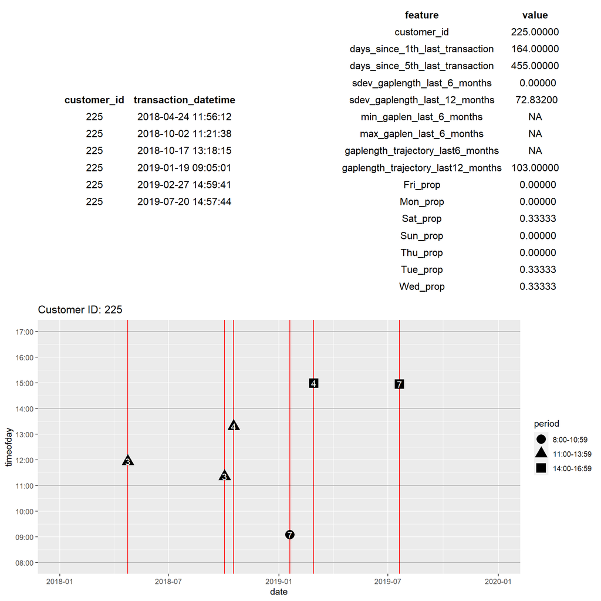

```
## [1] "Customer ID:"
## [1] 677
```

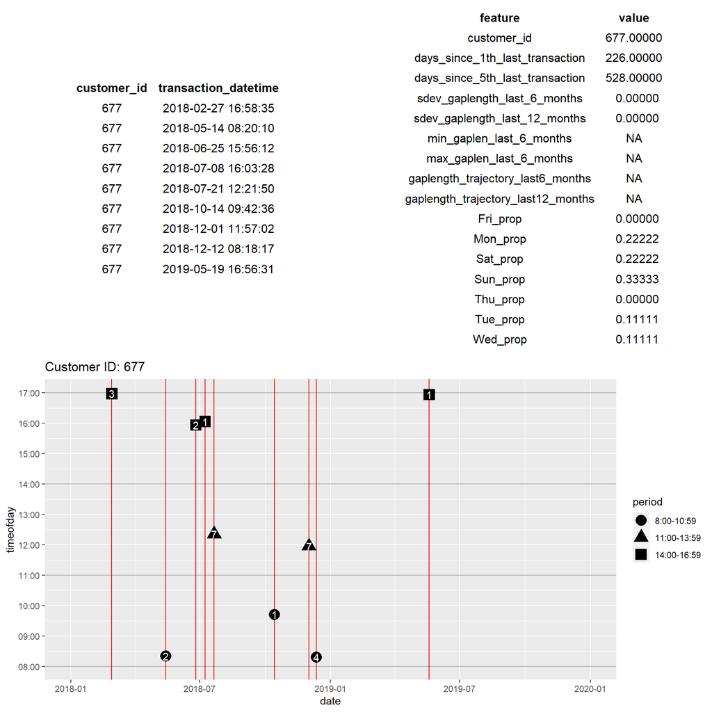

```
## [1] "Customer ID:"
## [1] 769
```

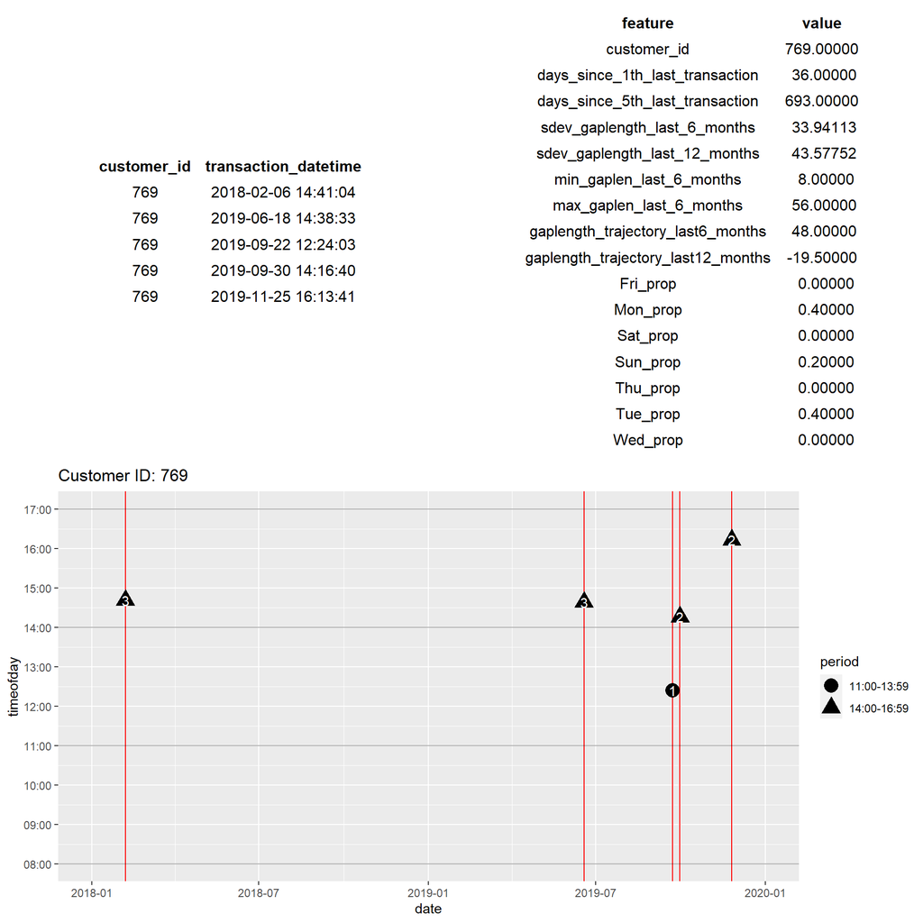

```
## [1] "Customer ID:"
## [1] 194
```

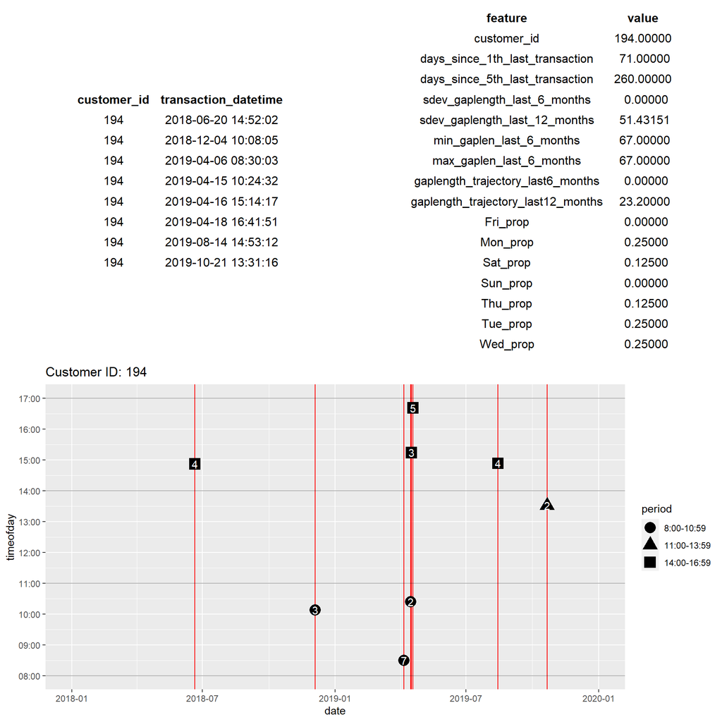

```
## [1] "Customer ID:"
## [1] 987
```

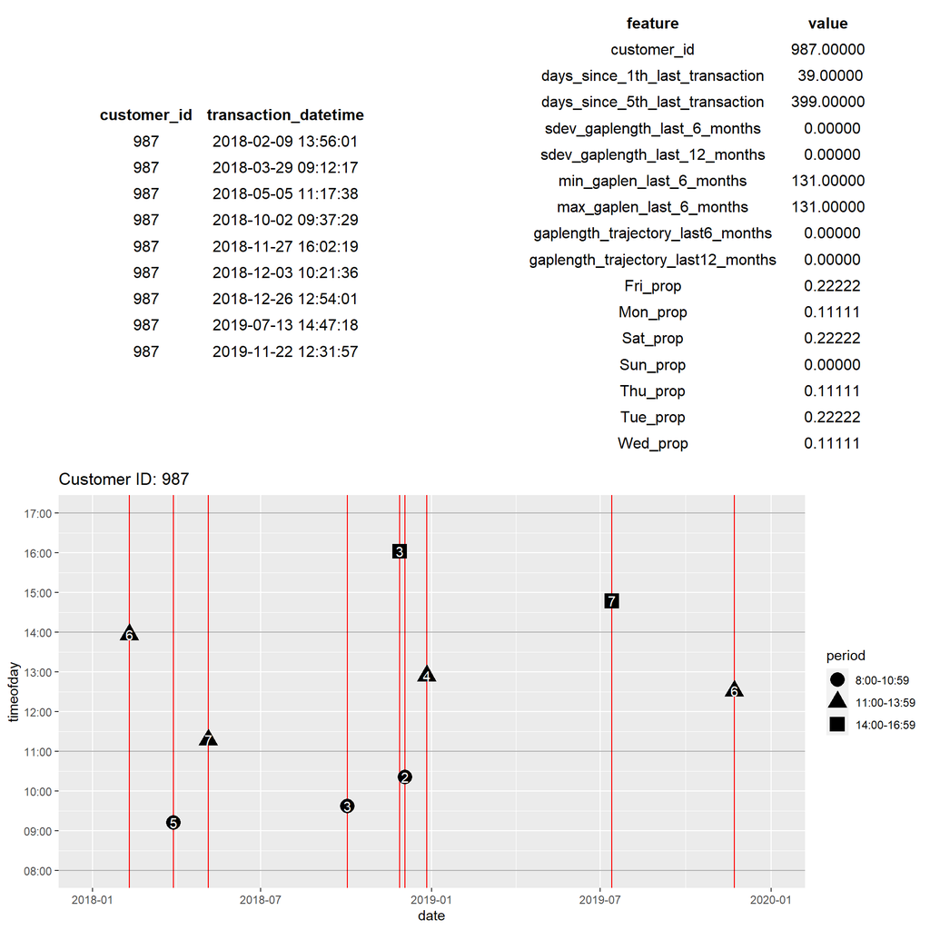

```
## [1] "Customer ID:"
## [1] 181
```

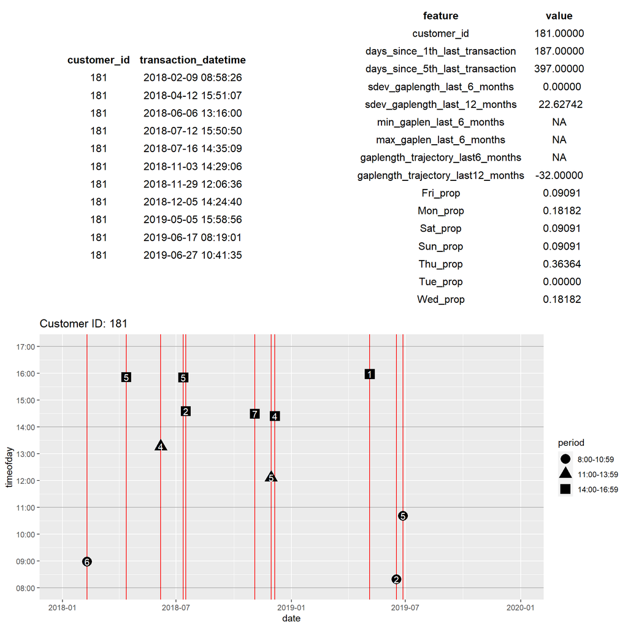

```
## [1] "Customer ID:"
## [1] 739
```

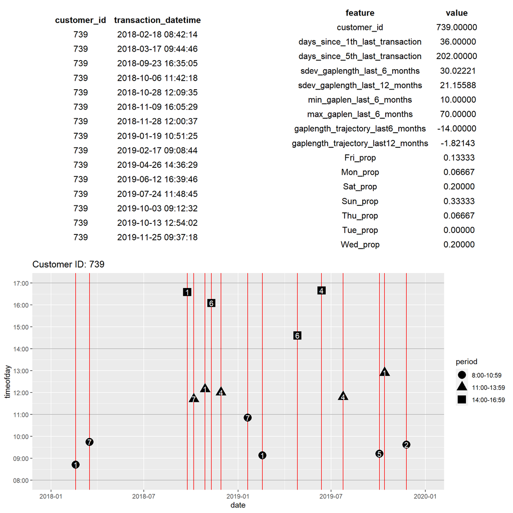

```
## [1] "Customer ID:"
## [1] 347
```

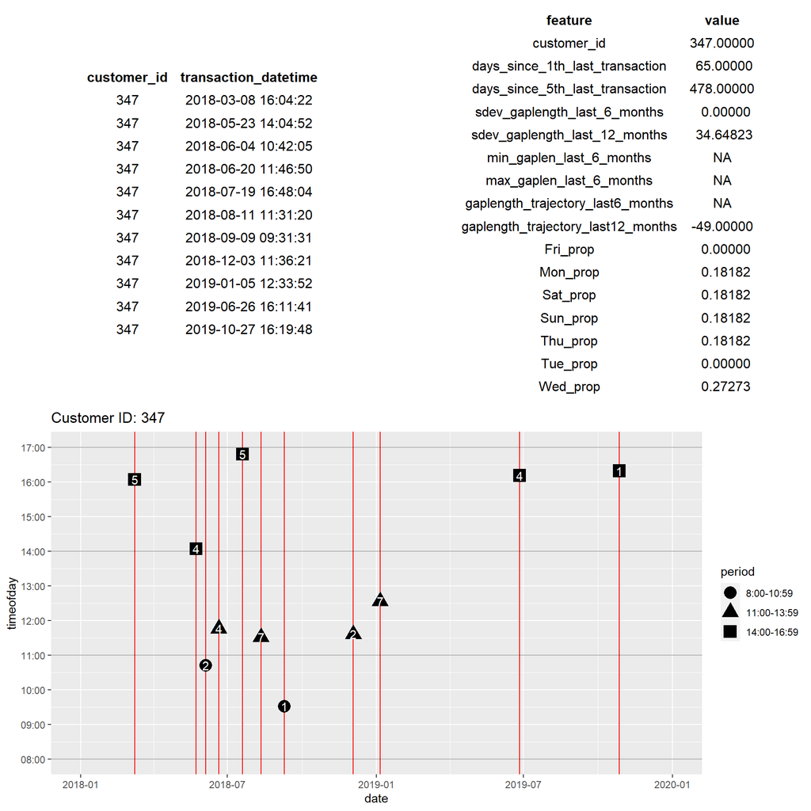

```
## [1] "Customer ID:"
## [1] 156
```

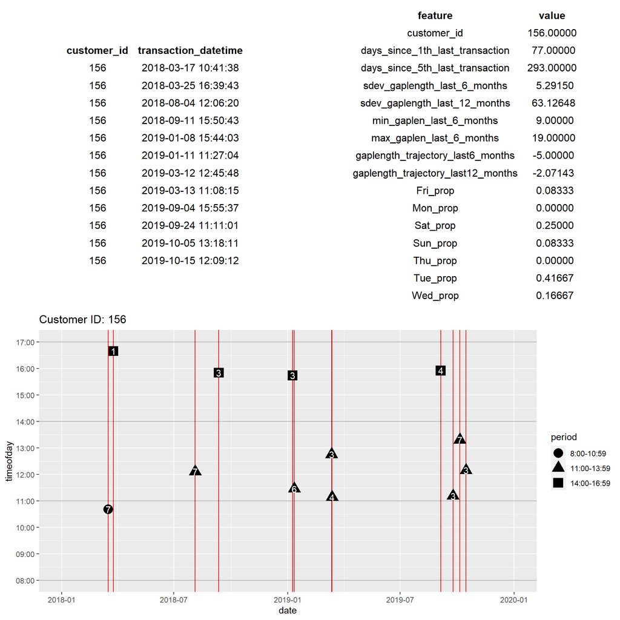

```
## [1] "Customer ID:"
## [1] 425
```

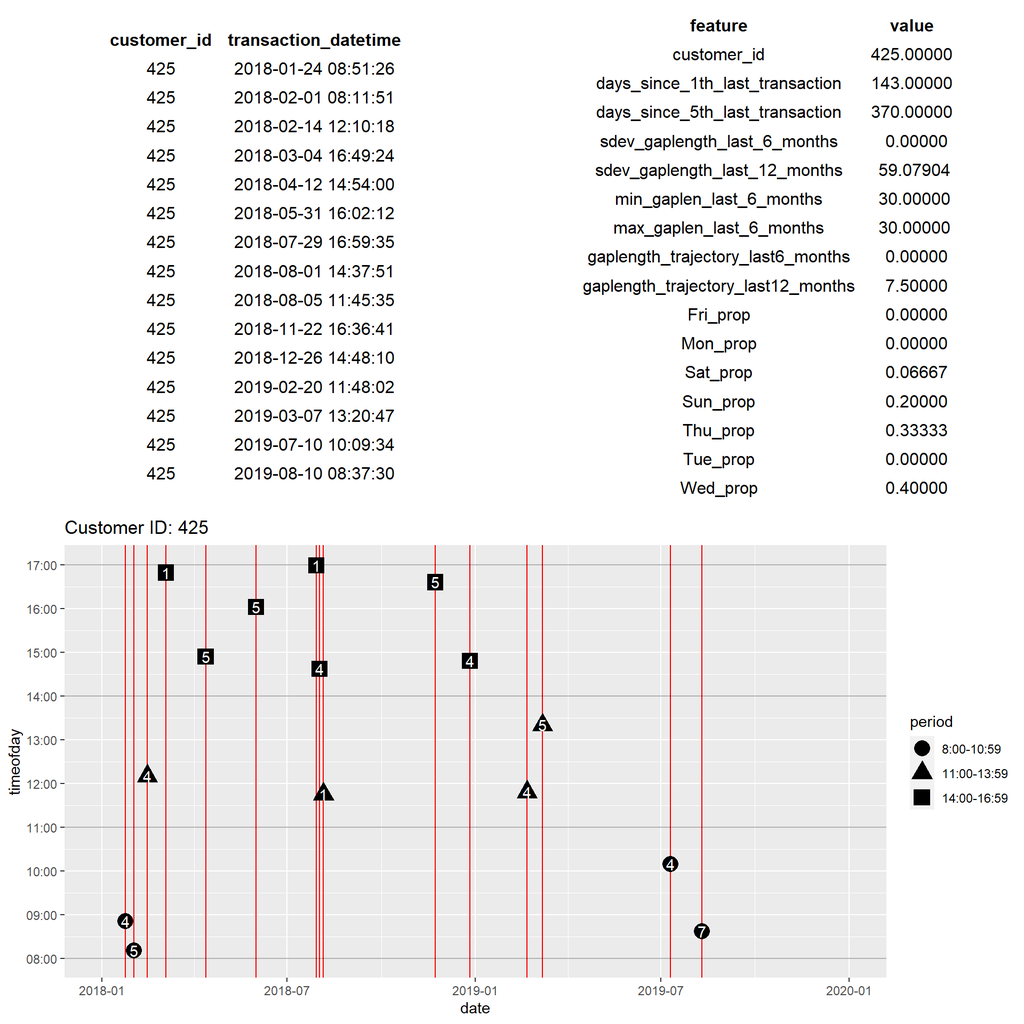

```
## [1] TRUE
```